# Baby Names Trend

### **Introduction**

**Problem Statement:**

Yesterday, Today and Tomorrow, one thing that is never going to change is the challenge and excitement of selecting a name for a new born baby. Our objective here is to analyze and show few interesting trends and results of the babynames from 1964-2018

**Insights:**

- Cardinal Cognizance: Analyzing cardinal points such as total birth in Ireland, First letter and most popular name trends
- Diversity in Names : Unisex names trend, transition in Unisex Names analysis and growth of name diversity.
- Entertaining Study : Studying the trend in Irish Names, affect of Immigration, books and pop-singers in babynames

### **Packages Required**

These are the required packages for this project :

- Tidyverse
- Plyr
- dplyr
- ggplot2
- stringr
- readr

```r
library(plyr)
library(tidyverse)
library(ggplot2)
library(stringr)
library(readr)
library(dplyr)
library(tm)
library(wordcloud)
library(RColorBrewer)
```

### **Exploratory Data Analysis & Data Preparation**

#### Data Import

The data set is downloaded from “https://www.cso.ie/en/interactivezone/visualisationtools/babynamesofireland/” where we had 110 csv files from year 1964 to 2018 (Boy and Girl) This dataset contains 68508 entries divided as male and female for around 55 years in Ireland.

Data consists of only three columns (“Name”, “Rank” and “Number of Births”)

*Sample Data :*

*Male*

```r
baby_names_boys <- list.files(path= "boys dataset"
                              , pattern="*.csv", full.names=TRUE)
dat_csv_boy<- ldply(baby_names_boys,read_csv)
sample_n(dat_csv_boy,5)
```

```
##        Name Rank Number of Births
## 1    Walter  550                5
## 2    Keenan  369                3
## 3     Tadhg  212                9
## 4  Ruaidhri  601                4
## 5 Augustine  125               19
```

*Female*

```r
baby_names_girls <- list.files(path= "girls dataset",
                               pattern="*.csv", full.names=TRUE)
dat_csv_grl<- ldply(baby_names_girls,read_csv)
sample_n(dat_csv_grl,5)
```

```
##    Name Rank Number of Births
## 1 Grace  118               44
## 2 Erika  315                9
## 3 Hafsa  873                3
## 4 Niamh   59              104
## 5 Guste  689                3
```

Using ldply and lapply data is read from csv and added two other columns “Year” and “Sex” were added whose values were taken from the file name with the help of regex expression. Year and sex had been added to every column using repeat functionality.

*Sample Data :*

```r
# For Male data set


dat_csv_boy$year<-0                                          # New columm for Year
year<-lapply(baby_names_boys,function(x) str_extract(x,"\\d{4}"))
tcount_eachyear_boys<-lapply(baby_names_boys, function(x) nrow(read.csv(x)))
dat_csv_boy$year<-rep(year,tcount_eachyear_boys)
dat_csv_boy$sex<-"Male"                                     # New columm for Male Gender


# For Female data set


dat_csv_grl$year<-0                                          # New columm for Year
year<-lapply(baby_names_girls,function(y) str_extract(y,"\\d{4}"))
tcount_eachyear_girls<-lapply(baby_names_girls, function(x) nrow(read.csv(x)))
dat_csv_grl$year<-rep(year,tcount_eachyear_girls)
dat_csv_grl$sex<-"Female"                                   # New columm for Female Gender

sample_n(dat_csv_grl,5)
```

```
##      Name Rank Number of Births year    sex
## 1    Cleo  515                3 1991 Female
## 2 Alyssia  907                3 2012 Female
## 3  Saidbh  894                3 2013 Female
## 4   Tracy   87               92 1983 Female
## 5  Soraya  582                6 2009 Female
```

```r
sample_n(dat_csv_boy,5)
```

```
##      Name Rank Number of Births year  sex
## 1 Malcolm  711                3 2013 Male
## 2  Aodhan  209               27 2009 Male
## 3   Frank  219               24 2008 Male
## 4  Barrie  251                6 1974 Male
## 5  Keiran  250                3 1965 Male
```

Male and Female data was loaded and combined into single data frame for analysis.

*Sample Data :*

```r
# Combining both the Boy and Girl Data set

cmbd_boy_girl_data <- rbind(dat_csv_boy, dat_csv_grl)

# Added column and changing datatye over the Data set

names(cmbd_boy_girl_data)[3] <- "No_of_bth"
cmbd_boy_girl_data$numbofrecords <- 1
cmbd_boy_girl_data$year <- as.numeric(cmbd_boy_girl_data$year) #list is converted to Numeric

sample_n(cmbd_boy_girl_data,5)
```

```
##      Name Rank No_of_bth year    sex numbofrecords
## 1    Saul  336        12 2012   Male             1
## 2 Ariella  750         4 2016 Female             1
## 3    Esme  185        28 2018 Female             1
## 4  Serena  262        14 1988 Female             1
## 5  Stacey  225        15 2001 Female             1
```

```r
# Subset for Unisex Names Analysis

sbst1<-sapply(dat_csv_boy$Name, function(x) x %in% dat_csv_grl$Name)
sbst2 <-sapply(dat_csv_grl$Name, function(x) x %in% dat_csv_boy$Name)
cmbd_boy_girl_data$unisexnames <- c(sbst1,sbst2)
```

#### Data Cleaning

On analysing the data there were a few spurious characters like ‘Á’,‘É’,‘Í’,‘Ó’,‘Ú’.

*Sample Data:*

```r
spuChar <- sapply(colnames(cmbd_boy_girl_data), function(x) grep("Á", cmbd_boy_girl_data[,x]))
spuChar1 <- sapply(colnames(cmbd_boy_girl_data), function(x) grep("Í", cmbd_boy_girl_data[,x]))

cmbd_boy_girl_data[spuChar$Name[1],]
```

```
##       Name Rank No_of_bth year  sex numbofrecords unisexnames
## 28117 Áron  749         3 2018 Male             1       FALSE
```

```r
cmbd_boy_girl_data[spuChar1$Name[1],]
```

```
##        Name Rank No_of_bth year  sex numbofrecords unisexnames
## 28133 Íarla  749         3 2018 Male             1       FALSE
```

These spurious characters ‘Á’,‘É’,‘Í’,‘Ó’,‘Ú’ has replaced as ‘A’,‘E’,‘I’,‘O’ and ‘U’ using sapply() respectively for one of the analysis in this project.

*Sample Data:*

```r
data_letter_analysis <- cmbd_boy_girl_data
data_letter_analysis$Name <- (sapply(data_letter_analysis$Name,gsub,pattern="\\Á",replacement="A"))
  data_letter_analysis$Name <-  (sapply(data_letter_analysis$Name,gsub,pattern="\\É",replacement="E"))
  data_letter_analysis$Name <-  (sapply(data_letter_analysis$Name,gsub,pattern="\\Í",replacement="I"))
  data_letter_analysis$Name <-  (sapply(data_letter_analysis$Name,gsub,pattern="\\Ó",replacement="O"))
  data_letter_analysis$Name <- (sapply(data_letter_analysis$Name,gsub,pattern="\\Ú",replacement="U"))

data_letter_analysis[spuChar$Name[1],]
```

```
##       Name Rank No_of_bth year  sex numbofrecords unisexnames
## 28117 Aron  749         3 2018 Male             1       FALSE
```

```r
data_letter_analysis[spuChar1$Name[1],]
```

```
##        Name Rank No_of_bth year  sex numbofrecords unisexnames
## 28133 Iarla  749         3 2018 Male             1       FALSE
```

#### Data Preview

20 rows of the data are listed below, it contains ‘Name’,‘Rank’, ‘Number of Births’,‘year’,‘sex’

*Sample Data:*

```r
sample_n(cmbd_boy_girl_data,20)
```

```
##        Name Rank No_of_bth year    sex numbofrecords unisexnames
## 1     Olive  304        10 1988 Female             1       FALSE
## 2      Katy  304        10 1997 Female             1       FALSE
## 3    Alison   73       120 1976 Female             1       FALSE
## 4     Lydia  195        31 1981 Female             1       FALSE
## 5     Breda  150        38 1970 Female             1       FALSE
## 6     Daran  288         4 1974   Male             1       FALSE
## 7      Zara   69        97 2015 Female             1       FALSE
## 8    Naoimh  576         3 1997 Female             1       FALSE
## 9    Triona  215        21 1985 Female             1       FALSE
## 10     Alan   21       373 1991   Male             1       FALSE
## 11   Daniel   25       373 1980   Male             1       FALSE
## 12   Winnie  579         6 2017 Female             1       FALSE
## 13    Vicky  322        10 1980 Female             1       FALSE
## 14    Harry  322         3 1981   Male             1       FALSE
## 15   Claire   16       349 1991 Female             1       FALSE
## 16     Josh  208        11 1996   Male             1       FALSE
## 17 Clionadh  496         4 1997 Female             1       FALSE
## 18     Judy  456         4 1985 Female             1       FALSE
## 19     Dana  873         3 2018 Female             1       FALSE
## 20  Cillian   21       351 2010   Male             1       FALSE
```

### **Analyzing Data and visualizations**

#### Cardinal Cognizance

**Total Birth In Ireland**

From 2000, the population surged in 10 years and again it began to dwindle in the forthcoming years.

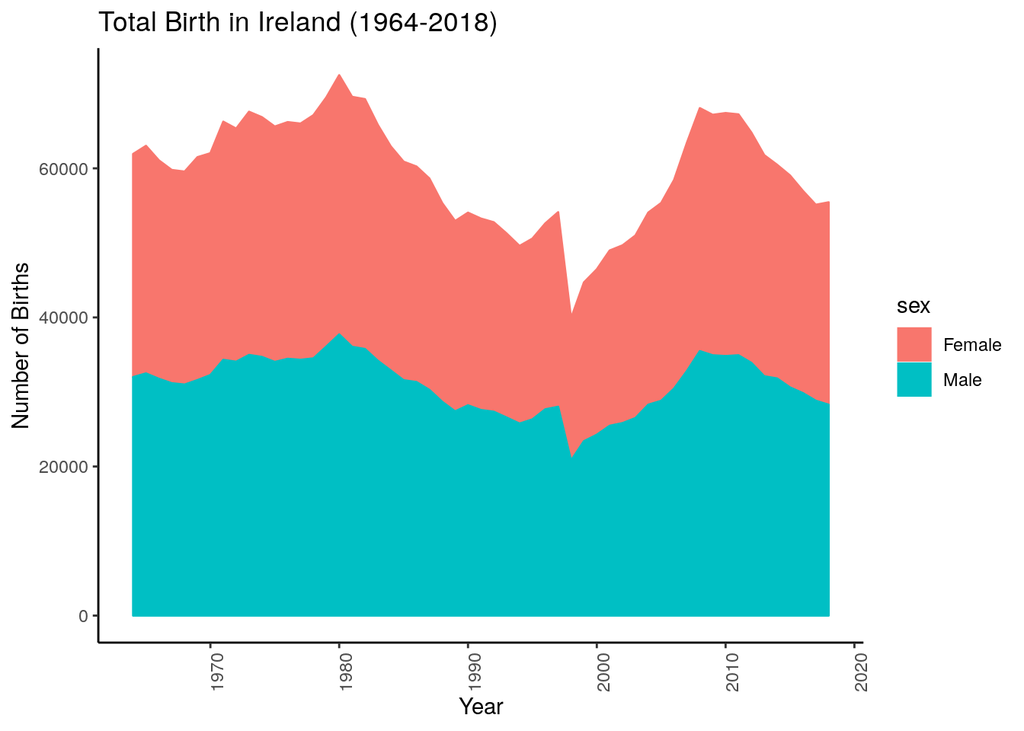

```r
grlboybrth <- cmbd_boy_girl_data  %>% group_by(Name,year,sex) %>% summarise(totlbrth = sum(No_of_bth))
summ_year_sex <- grlboybrth %>% group_by(year,sex) %>% summarise(t = sum(totlbrth))
Area_graph <- ggplot(summ_year_sex, mapping = aes(x = year, y =t, fill = sex, group = sex))+
  geom_area(aes(colour = sex)) +   theme_classic() +
  theme(axis.text.x = element_text(angle = 90, hjust = 1))+
  ggtitle("Total Birth in Ireland (1964-2018)") + labs(x="Year", y="Number of Births")
Area_graph
```

**First Letter/Alphabet of Baby Names**

In a few countries/regions it is conventional to first figure out the first letter and then befit a name, hence this is to interpret Ireland’s most popular ‘First Alphabet’ among baby names.

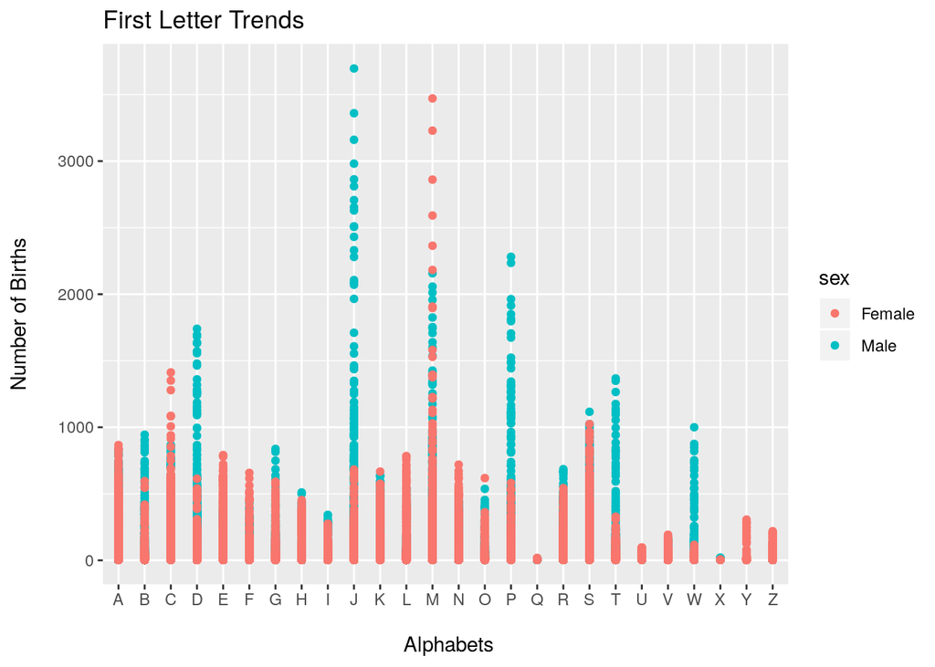

```r
data_letter_analysis$FirstLetter <- substr(data_letter_analysis$Name, start = 1, stop = 1)

ggplot(data = data_letter_analysis, aes(x = data_letter_analysis$FirstLetter, y = data_letter_analysis$No_of_bth)) +
  geom_point(aes(col=sex), stat="identity",position=position_dodge()) +
  geom_smooth(method="loess", se=F) +
  xlab("\n Alphabets") +
  ylab("Number of Births\n") +
  ggtitle("First Letter Trends")
```

**Trend in Most Popular Names**

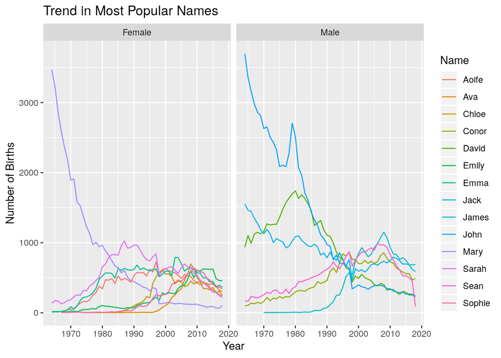

```r
names <- unique(as.character(subset(cmbd_boy_girl_data,Rank==1)$Name))
rank1 <- subset(cmbd_boy_girl_data, Name %in% names)
d1 <- ggplot(rank1, aes(x=year, y=No_of_bth,color=Name))
d1 + geom_line() + facet_wrap(~sex) + xlab("Year") + ylab("Number of Births")+ggtitle("Trend in Most Popular Names")
```

This is the trend in names that had the top spot of names at some stage in the data, split into male and female graphs, there is a noticeable decline in the number of births of the name with most births, as well as a sharp drop in popularity of the most popular names at the beginning of the Data. (John & Mary)

#### Diversity in Names

**Unisex Name Trends**

Gender-neutral baby names are trending and there is an increase in this trend throughout the years.

This is an important concept as we see many datasets AI/ML models figure the sex of a person by the name and the data gets skewed because of which we get uneven results.

One of the famous examples being ‘salary’ trends among employees. Hence gender-neutral baby names are going to be very helpful for future data analysis.

[figure not shown]

```r
sepunisexname <- cmbd_boy_girl_data   %>% select(Name,sex,unisexnames,numbofrecords) %>%
   filter(unisexnames =="TRUE") %>%
  group_by(Name,sex,unisexnames) %>% summarise(Births =sum(numbofrecords))

unisexname <- sepunisexname %>%  group_by(Name) %>%
  mutate(total = ifelse(Name == Name, sum(Births), NA)) %>%
  arrange(desc(total)) %>% head(n=20)

TpunisexName <- ggplot(unisexname, aes(x = reorder(Name,+Births),Births))+
geom_bar(position = position_stack(),aes(fill = sex) ,stat = "identity")+
xlab("Names") + ylab("Number of Births") + coord_flip() +
  geom_text(aes(label = Births),position = position_stack(vjust = .5)) +
  ggtitle("Top Unisex Names in Ireland (1964-2018)")
TpunisexName
```

**Transition in Unisex Names**

An interesting insight into Unisex names is to observe the transition from Male to Female and vice-versa throughout the period (1964-2018).

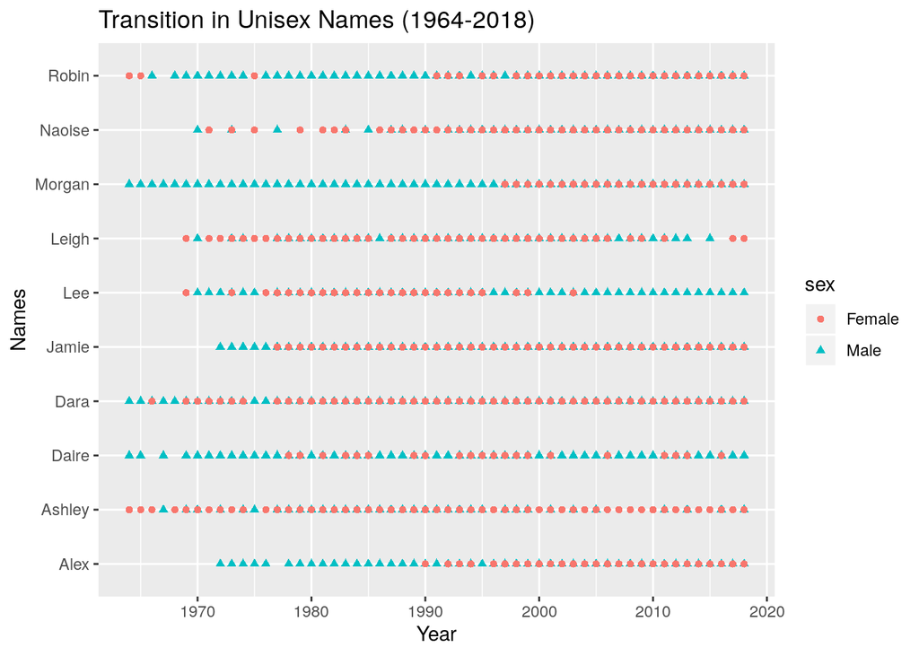

```r
GenderTrans <- c(unisexname$Name)
GenTrans <- subset(cmbd_boy_girl_data,((Name %in% c(GenderTrans))&(sex=="Female"))
                   |((Name %in% c(GenderTrans))&(sex=="Male")))
genplot <- ggplot(GenTrans, aes(x=year,y=Name,col=sex))
genplot + geom_point(aes(shape=sex))+ xlab("Year") +ylab("Names") + ggtitle("Transition in Unisex Names (1964-2018)")
```

**Growth of Name Diversity**

The drop in popularity of the most popular name is reflected in the increase in unique names with time. The number of unique names on the list more than doubles by 2018.

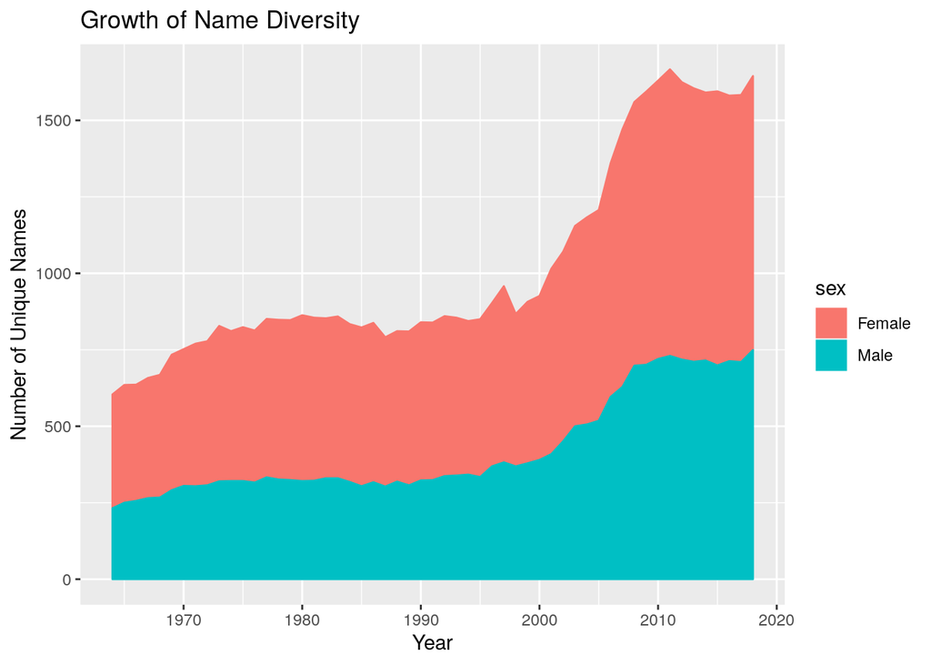

```r
UniqueNames <- summarise(group_by(cmbd_boy_girl_data,year,sex),No_Unique=max(Rank))
d1 <- ggplot(UniqueNames, aes(x=year,y=No_Unique,col=sex,fill=sex))
d1 + geom_area() + xlab("Year") + ylab("Number of Unique Names")+ ggtitle("Growth of Name Diversity")
```

#### Entertaining Study

**Irish-Gaelic Baby Names :**

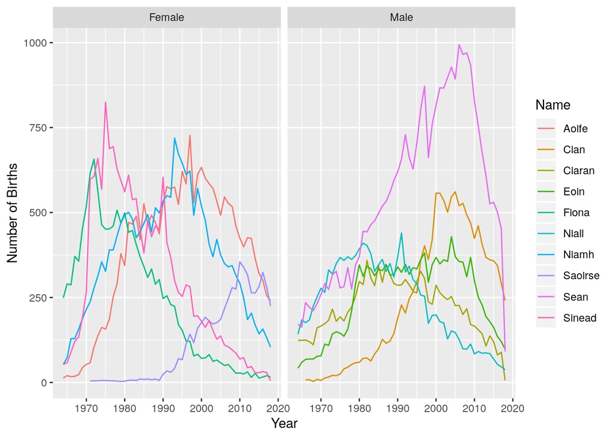

```r
PopIrG <- c("Aoife","Sinead","Niamh","Fiona","Saoirse")
PopIrB <- c("Niall","Ciaran","Eoin","Cian","Sean")

PopIrSub <- subset(cmbd_boy_girl_data,((Name %in% c(PopIrG))&(sex=="Female"))
                   |((Name %in% c(PopIrB))&(sex=="Male")))
d1 <- ggplot(PopIrSub, aes(x=year,y=No_of_bth,col=Name))
d1 + geom_line() + xlab("Year") +ylab("Number of Births")+facet_wrap(~sex)
```

**Polish Baby Names (Impact of Immigration):**

The Polish community is the largest non-Irish group living and working in Ireland. Ireland opened its borders to Polish nationals in 2004 when Poland joined the EU. The rise in traditional Polish names given to babies is evident in the two-line graphs above.

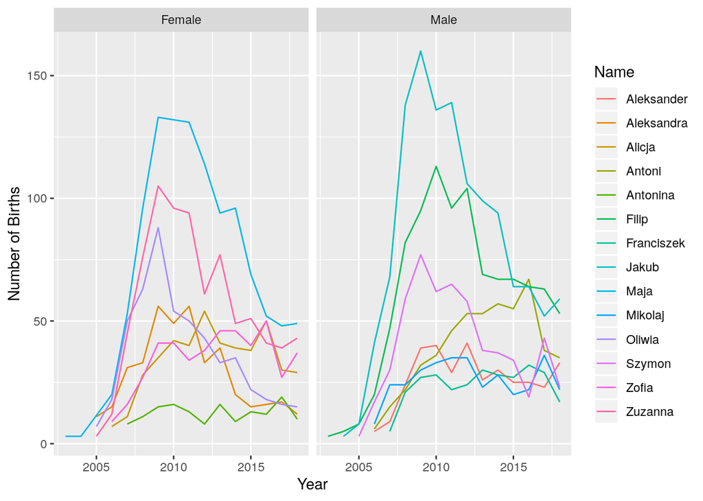

```r
PopB <- c("Antoni","Jakub","Szymon","Franciszek","Filip","Aleksander","Mikolaj")
PopG <- c("Zuzanna","Zofia","Maja","Alicja","Aleksandra","Oliwia","Antonina")

PopSub <- subset(cmbd_boy_girl_data,((Name %in% c(PopG))&(sex=="Female"))
                   |((Name %in% c(PopB))&(sex=="Male")))

d2 <- ggplot(PopSub, aes(x=year,y=No_of_bth,col=Name))
d2 + geom_line() + xlab("Year") +ylab("Number of Births")+facet_wrap(~sex)
```

**How Books and Pop-Singers influenced Baby Names?**

The popular US singers named in the above graph have affected Irish baby names. The first appearance of the of Britney in the data first occured in the late 1990s, when she released her fist song. As her popularity decreased, so did the number of babies born with that name. The names Miley and Ariana started to become popular in the 2010s.

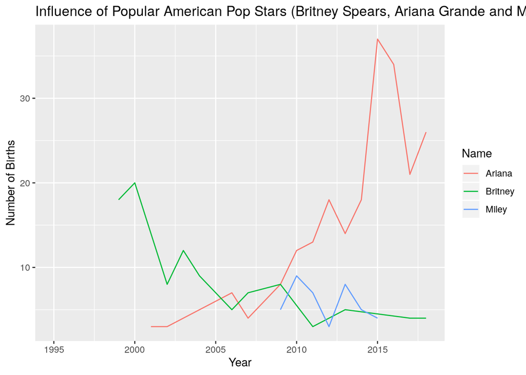

```r
PopSingers <- c("Miley", "Ariana", "Britney")
PopSingerSub <- subset(cmbd_boy_girl_data,(Name %in% c(PopSingers)& (sex =="Female")))
PopGraph <- ggplot(PopSingerSub, aes(x = year, y = No_of_bth, col = Name)) + geom_line() + expand_limits(x= 1995) + ggtitle("Influence of Popular American Pop Stars (Britney Spears, Ariana Grande and Miley Cyrus)")+ labs(x = "Year", y = "Number of Births")
PopGraph
```

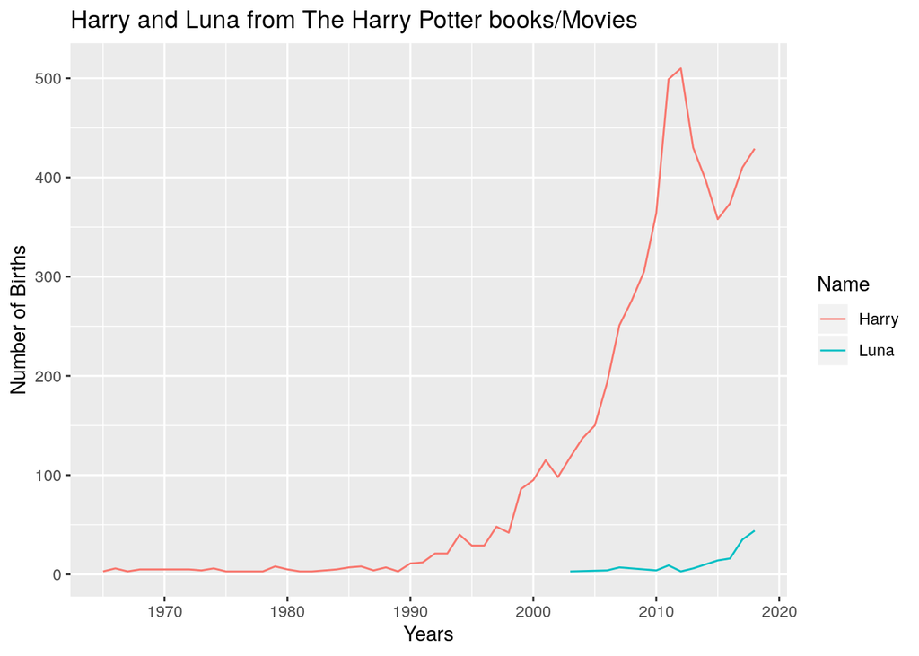

```r
HPHarry <- subset(cmbd_boy_girl_data, Name == "Harry" & sex == "Male");HPLuna <- subset(cmbd_boy_girl_data, Name == "Luna")
HP <- bind_rows(HPHarry, HPLuna)

ggplot(data = HP, aes(x = year, y = No_of_bth, color = Name)) + geom_line() + ggtitle("Harry and Luna from The Harry Potter books/Movies")+ labs(x = "Years", y = "Number of Births")
```